# Lecture 8. Overview of methods

November 3, 2019

## Дерева рішень

```r
library(party)
```

## Побудувати предиктор на основі регресії

```r
train <- readingSkills[c(1:120),]
test <- readingSkills[c(121:200),]
```

## Регресія

```r
lm_score <- lm(score ~ ., data = train)
show <- readingSkills
show$prediction <- predict(lm_score, show)
```

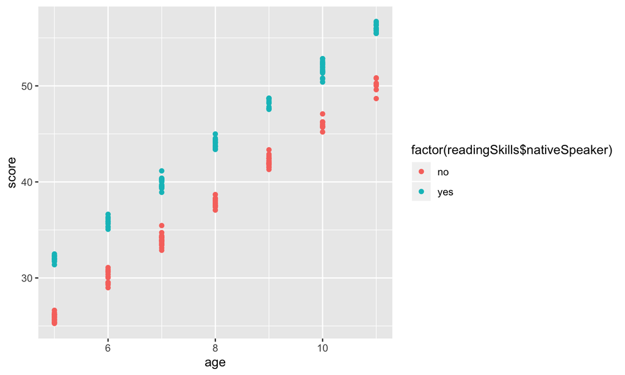

```r
ggplot(data = readingSkills, aes(age, score)) +
  geom_point(aes(colour = factor(readingSkills$nativeSpeaker)))
```

## Дерева рішень

> A Decision Tree is a Supervised Machine Learning algorithm which looks like an inverted tree, wherein each node represents a predictor variable (feature), the link between the nodes represents a Decision and each leaf node represents an outcome (response variable).

```r
library(rpart)
# Create the tree.
  output.tree <- rpart(
  nativeSpeaker ~ age + shoeSize + score,
  data = train)
```

```r
library(rattle)
```

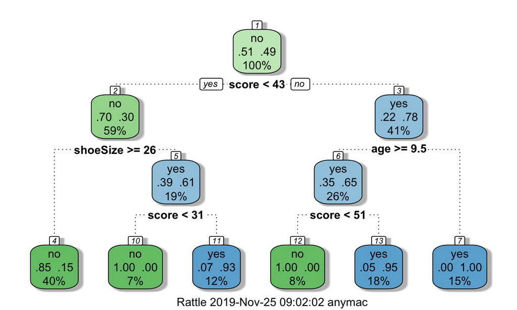

```r
library(rpart.plot)
library(RColorBrewer)
fancyRpartPlot(output.tree)
```

## Випадкові ліси

```r
# Load the party package. It will automatically load other
# required packages.
library(randomForest)
# Create the forest.
output.forest <- randomForest(nativeSpeaker ~ age + shoeSize + score,
           data = readingSkills)
```

```r
# View the forest results.
print(output.forest)
```

```
##
## Call:
##  randomForest(formula = nativeSpeaker ~ age + shoeSize + score,      data = readingSkills)
##                Type of random forest: classification
##                      Number of trees: 500
## No. of variables tried at each split: 1
##
##         OOB estimate of  error rate: 1%
## Confusion matrix:
##     no yes class.error
## no  99   1        0.01
## yes  1  99        0.01
```

```r
library(AppliedPredictiveModeling)
data(abalone)
```

## Базова модель

```r
library(ISLR)
data(Wage)
summary(Wage)
```

```
##       year           age                     maritl           race
##  Min.   :2003   Min.   :18.00   1. Never Married: 648   1. White:2480
##  1st Qu.:2004   1st Qu.:33.75   2. Married      :2074   2. Black: 293
##  Median :2006   Median :42.00   3. Widowed      :  19   3. Asian: 190
##  Mean   :2006   Mean   :42.41   4. Divorced     : 204   4. Other:  37
##  3rd Qu.:2008   3rd Qu.:51.00   5. Separated    :  55
##  Max.   :2009   Max.   :80.00
##
##               education                     region               jobclass
##  1. < HS Grad      :268   2. Middle Atlantic   :3000   1. Industrial :1544
##  2. HS Grad        :971   1. New England       :   0   2. Information:1456
##  3. Some College   :650   3. East North Central:   0
##  4. College Grad   :685   4. West North Central:   0
##  5. Advanced Degree:426   5. South Atlantic    :   0
##                           6. East South Central:   0
##                           (Other)              :   0
##             health      health_ins      logwage           wage
##  1. <=Good     : 858   1. Yes:2083   Min.   :3.000   Min.   : 20.09
##  2. >=Very Good:2142   2. No : 917   1st Qu.:4.447   1st Qu.: 85.38
##                                      Median :4.653   Median :104.92
##                                      Mean   :4.654   Mean   :111.70
##                                      3rd Qu.:4.857   3rd Qu.:128.68
##                                      Max.   :5.763   Max.   :318.34
##
```

## Побудуємо лінійну залежність

```r
lm_wage <- lm(wage ~ age, data = Wage)
unseen <- data.frame(age = 60)
predict(lm_wage, unseen)
```

```
##        1
## 124.1413
```

## Категорії проблем

- класифікація
- регресія
- кластерізація

## Практичне застосування навчання з вчителем

```r
str(iris)
```

```
## 'data.frame':    150 obs. of  5 variables:
##  $ Sepal.Length: num  5.1 4.9 4.7 4.6 5 5.4 4.6 5 4.4 4.9 ...
##  $ Sepal.Width : num  3.5 3 3.2 3.1 3.6 3.9 3.4 3.4 2.9 3.1 ...
##  $ Petal.Length: num  1.4 1.4 1.3 1.5 1.4 1.7 1.4 1.5 1.4 1.5 ...
##  $ Petal.Width : num  0.2 0.2 0.2 0.2 0.2 0.4 0.3 0.2 0.2 0.1 ...
##  $ Species     : Factor w/ 3 levels "setosa","versicolor",..: 1 1 1 1 1 1 1 1 1 1 ...
```

```r
summary(iris)
```

```
##   Sepal.Length    Sepal.Width     Petal.Length    Petal.Width
##  Min.   :4.300   Min.   :2.000   Min.   :1.000   Min.   :0.100
##  1st Qu.:5.100   1st Qu.:2.800   1st Qu.:1.600   1st Qu.:0.300
##  Median :5.800   Median :3.000   Median :4.350   Median :1.300
##  Mean   :5.843   Mean   :3.057   Mean   :3.758   Mean   :1.199
##  3rd Qu.:6.400   3rd Qu.:3.300   3rd Qu.:5.100   3rd Qu.:1.800
##  Max.   :7.900   Max.   :4.400   Max.   :6.900   Max.   :2.500
##        Species
##  setosa    :50
##  versicolor:50
##  virginica :50
##
##
##
```

```r
set.seed(1)
library(rpart)
tree <- rpart(Species ~ Sepal.Length + Sepal.Width + Petal.Length + Petal.Width, data = iris, method = "class")
```

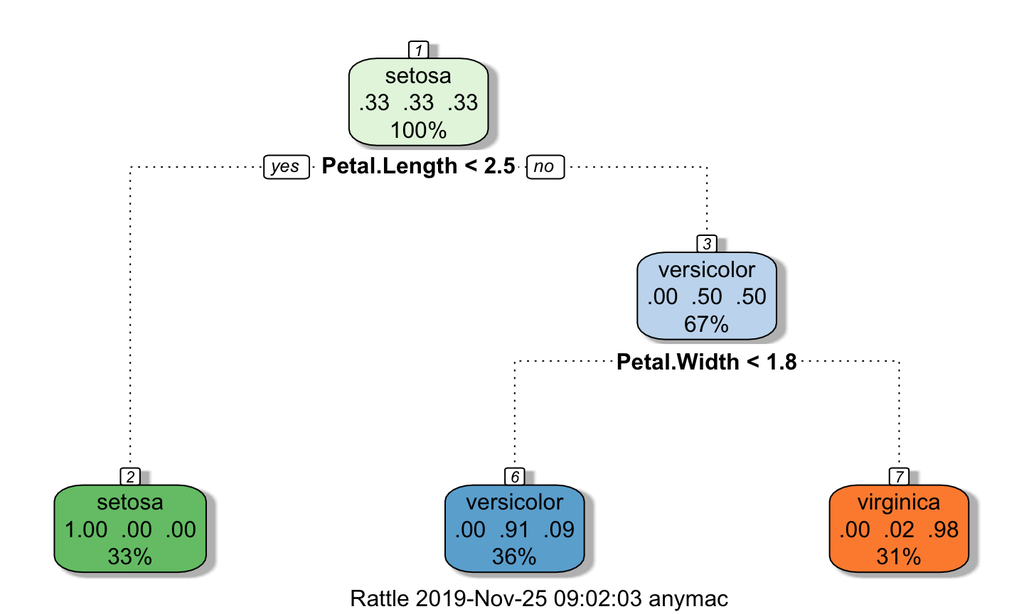

```r
library(rattle)
library(rpart.plot)
library(RColorBrewer)
fancyRpartPlot(tree)
```

```r
unseen <- data.frame(Sepal.Length = c(5.3, 7.2),
                     Sepal.Width = c(2.9, 3.9),
                     Petal.Length = c(1.7, 5.4),
                     Petal.Width = c(0.8, 2.3))
```

```r
unseen
```

```
##   Sepal.Length Sepal.Width Petal.Length Petal.Width
## 1          5.3         2.9          1.7         0.8
## 2          7.2         3.9          5.4         2.3
```

```r
predict(tree, unseen, type = "class")
```

```
##         1         2
##    setosa virginica
## Levels: setosa versicolor virginica
```

## Почитати про методи

https://bradleyboehmke.github.io/HOML/DT.html

## Набір Ames. Продаж будинків.

```r
ames <- read.csv('ames.csv', header = T)
str(ames)
```

```
## 'data.frame':    2930 obs. of  82 variables:
##  $ Order          : int  1 2 3 4 5 6 7 8 9 10 ...
##  $ PID            : int  526301100 526350040 526351010 526353030 527105010 527105030 527127150 527145080 527146030 527162130 ...
##  $ MS.SubClass    : int  20 20 20 20 60 60 120 120 120 60 ...
##  $ MS.Zoning      : Factor w/ 7 levels "A (agr)","C (all)",..: 6 5 6 6 6 6 6 6 6 6 ...
##  $ Lot.Frontage   : int  141 80 81 93 74 78 41 43 39 60 ...
##  $ Lot.Area       : int  31770 11622 14267 11160 13830 9978 4920 5005 5389 7500 ...
##  $ Street         : Factor w/ 2 levels "Grvl","Pave": 2 2 2 2 2 2 2 2 2 2 ...
##  $ Alley          : Factor w/ 2 levels "Grvl","Pave": NA NA NA NA NA NA NA NA NA NA ...
##  $ Lot.Shape      : Factor w/ 4 levels "IR1","IR2","IR3",..: 1 4 1 4 1 1 4 1 1 4 ...
##  $ Land.Contour   : Factor w/ 4 levels "Bnk","HLS","Low",..: 4 4 4 4 4 4 4 2 4 4 ...
##  $ Utilities      : Factor w/ 3 levels "AllPub","NoSeWa",..: 1 1 1 1 1 1 1 1 1 1 ...
##  $ Lot.Config     : Factor w/ 5 levels "Corner","CulDSac",..: 1 5 1 1 5 5 5 5 5 5 ...
##  $ Land.Slope     : Factor w/ 3 levels "Gtl","Mod","Sev": 1 1 1 1 1 1 1 1 1 1 ...
##  $ Neighborhood   : Factor w/ 28 levels "Blmngtn","Blueste",..: 16 16 16 16 9 9 25 25 25 9 ...
```

[output cut: 68 more lines]

## Семплінг

```r
# Using base R
set.seed(123)  # for reproducibility
index_1 <- sample(1:nrow(ames), round(nrow(ames) * 0.7))
train_1 <- ames[index_1, ]
test_1  <- ames[-index_1, ]
```

## Using caret package

```r
library(caret)
set.seed(123)  # for reproducibility

index_2 <- createDataPartition(ames$SalePrice, p = 0.7, list = FALSE)

train_2 <- ames[index_2, ]

test_2  <- ames[-index_2, ]
```

## Using rsample package

```r
library(rsample)
set.seed(123)  # for reproducibility

split_1  <- initial_split(ames, prop = 0.7)
train_3  <- training(split_1)
test_3   <- testing(split_1)
```

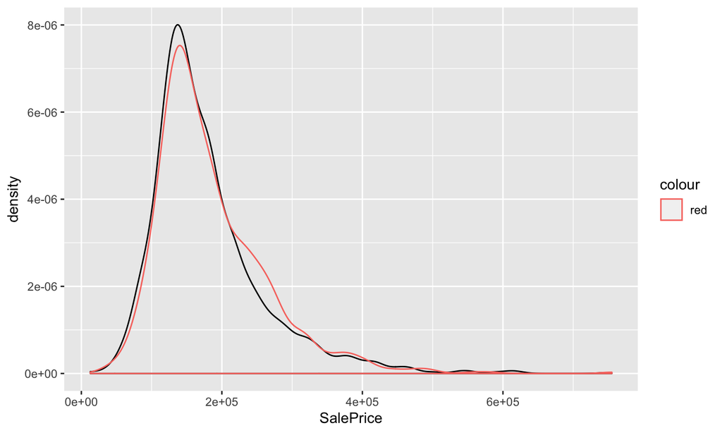

```r
library(ggplot2)
ggplot(data = train_1, aes(SalePrice)) +
  geom_density() +
  geom_density(data = test_1,aes(SalePrice, colour = "red"))
```

```r
model1 <- lm(SalePrice ~ Gr.Liv.Area, data = train_1)
summary(model1)
```

```
##
## Call:
## lm(formula = SalePrice ~ Gr.Liv.Area, data = train_1)
##
## Residuals:
##     Min      1Q  Median      3Q     Max
## -478762  -30030   -1405   22273  335855
##
## Coefficients:
##              Estimate Std. Error t value Pr(>|t|)
## (Intercept) 14045.872   3942.503   3.563 0.000375 ***
## Gr.Liv.Area   110.726      2.506  44.185  < 2e-16 ***
## ---
## Signif. codes:  0 '***' 0.001 '**' 0.01 '*' 0.05 '.' 0.1 ' ' 1
##
## Residual standard error: 57430 on 2049 degrees of freedom
## Multiple R-squared:  0.4879, Adjusted R-squared:  0.4877
## F-statistic:  1952 on 1 and 2049 DF,  p-value: < 2.2e-16
```

## Метод KNN

K-nearest neighbor (KNN) is a very simple algorithm in which each observation is predicted based on its “similarity” to other observations. Unlike most methods in this book, KNN is a memory-based algorithm and cannot be summarized by a closed-form model. This means the training samples are required at run-time and predictions are made directly from the sample relationships.

## Як міряти відстань

```r
two_houses <- train_1[1:2, c("Gr.Liv.Area", "Year.Built")]
dist(two_houses, method = "euclidean")
```

```
##          2463
## 2511 35.51056
```

```r
dist(two_houses, method = "manhattan")
```

```
##      2463
## 2511   41
```

## Відстань між двома довільними будинками (Фічами)

```r
home1 <- ames[1,]
home2 <- ames[2,]

features <- c("Bedroom.AbvGr", "Year.Built")
dist(rbind(home1[,features], home2[,features]))
```

```
##          1
## 2 1.414214
```

## Як працює КНН

```r
df <- data(iris) ##load data
 head(iris) ## see the studcture
```

```
##   Sepal.Length Sepal.Width Petal.Length Petal.Width Species
## 1          5.1         3.5          1.4         0.2  setosa
## 2          4.9         3.0          1.4         0.2  setosa
## 3          4.7         3.2          1.3         0.2  setosa
## 4          4.6         3.1          1.5         0.2  setosa
## 5          5.0         3.6          1.4         0.2  setosa
## 6          5.4         3.9          1.7         0.4  setosa
```

```r
 ran <- sample(1:nrow(iris), 0.9 * nrow(iris))

 ##the normalization function is created
 nor <-function(x) { (x -min(x))/(max(x)-min(x))   }

 ##Run nomalization on first 4 coulumns of dataset because they are the predictors
 iris_norm <- as.data.frame(lapply(iris[,c(1,2,3,4)], nor))

 summary(iris_norm)
```

```
##   Sepal.Length     Sepal.Width      Petal.Length     Petal.Width
##  Min.   :0.0000   Min.   :0.0000   Min.   :0.0000   Min.   :0.00000
##  1st Qu.:0.2222   1st Qu.:0.3333   1st Qu.:0.1017   1st Qu.:0.08333
##  Median :0.4167   Median :0.4167   Median :0.5678   Median :0.50000
##  Mean   :0.4287   Mean   :0.4406   Mean   :0.4675   Mean   :0.45806
##  3rd Qu.:0.5833   3rd Qu.:0.5417   3rd Qu.:0.6949   3rd Qu.:0.70833
##  Max.   :1.0000   Max.   :1.0000   Max.   :1.0000   Max.   :1.00000
```

```r
iris_train <- iris_norm[ran,]
##extract testing set
 iris_test <- iris_norm[-ran,]
 ##extract 5th column of train dataset because it will be used as 'cl' argument in knn function.
 iris_target_category <- iris[ran,5]
 ##extract 5th column if test dataset to measure the accuracy
 iris_test_category <- iris[-ran,5]
```

```r
 library(class)
 ##run knn function
 pr <- knn(iris_train,iris_test,cl=iris_target_category,k=13)

 ##create confusion matrix
 tab <- table(pr,iris_test_category)

 accuracy <- function(x){sum(diag(x)/(sum(rowSums(x)))) * 100}
 accuracy(tab)
```

```
## [1] 86.66667
```

## Завдання. Лаба 3-4

https://github.com/ignatenko/reserve-price

1. Дані - торги прозорро. Три варанти - яйця, …
2. Аналіз датасету і змінних.
3. Розділити на тренувальний і тестовий.
4. Побудувати регресійну модель (в залежності від характеру даних - лінійну або нелінійну). Оцінити точність прогнозу.
5. Побудувати дерево рішень для одної зі змінних (наприклад успішність, величина зменшення ціни при торгах). Побудувати модель випадковий ліс. Оцінити точність прогнозу.
6. Побудувати модель KNN. Оцінити точність прогнозу.